# Machine Learning Models for Static Malware Detection

### AIM: Find the best suitable classification model for malware detection.

```python
#import important Libraries which are required.
import numpy as np
import pandas as pd
import matplotlib.pyplot as plt
import plotly.express as px
import plotly.graph_objs as go
import plotly.offline as offline
import plotly.figure_factory as ff
import seaborn as sns
from kneed import KneeLocator
from sklearn.preprocessing import StandardScaler
from sklearn.decomposition import PCA
from sklearn.cluster import KMeans
from sklearn.preprocessing import LabelEncoder
from sklearn.preprocessing import StandardScaler
from sklearn.decomposition import PCA
from sklearn.model_selection import train_test_split
from sklearn import metrics
from sklearn.metrics import recall_score, precision_score, accuracy_score, f1_score,confusion_matrix
from collections import Counter
from imblearn.over_sampling import SMOTE
from imblearn.under_sampling import RandomUnderSampler
from imblearn.pipeline import Pipeline
from matplotlib import pyplot
import warnings
warnings.filterwarnings("ignore")
```

### 1. Data Reading & Analysis

```python
#importing DataSet
Malware=pd.read_csv("top_1000_pe_imports.csv")
```

```python
Malware.head()
```

|  | hash | GetProcAddress | ExitProcess | WriteFile | GetLastError | CloseHandle | FreeLibrary | Sleep | GetStdHandle | MultiByteToWideChar | ... | bind | RegEnumKeyExA | WinHttpOpen | _controlfp | WinExec | GetSecurityDescriptorDacl | FindFirstFreeAce | GetTimeFormatW | LookupAccountSidW | malware |
| --- | --- | --- | --- | --- | --- | --- | --- | --- | --- | --- | --- | --- | --- | --- | --- | --- | --- | --- | --- | --- | --- |
| 0 | 071e8c3f8922e186e57548cd4c703a5d | 1 | 1 | 1 | 1 | 1 | 1 | 1 | 1 | 1 | ... | 0 | 0 | 0 | 0 | 0 | 0 | 0 | 0 | 0 | 1 |
| 1 | 33f8e6d08a6aae939f25a8e0d63dd523 | 1 | 1 | 1 | 1 | 1 | 1 | 1 | 1 | 1 | ... | 0 | 0 | 0 | 0 | 0 | 0 | 0 | 0 | 0 | 1 |
| 2 | b68abd064e975e1c6d5f25e748663076 | 1 | 1 | 1 | 1 | 1 | 0 | 1 | 0 | 1 | ... | 0 | 1 | 0 | 0 | 0 | 0 | 0 | 0 | 0 | 1 |
| 3 | 72049be7bd30ea61297ea624ae198067 | 1 | 1 | 1 | 1 | 0 | 0 | 1 | 1 | 1 | ... | 0 | 0 | 0 | 0 | 0 | 0 | 0 | 0 | 0 | 1 |
| 4 | c9b3700a77facf29172f32df6bc77f48 | 1 | 1 | 1 | 1 | 1 | 1 | 1 | 1 | 1 | ... | 0 | 0 | 0 | 0 | 0 | 0 | 0 | 0 | 0 | 1 |

5 rows × 1002 columns

```python
Malware.tail()
```

|  | hash | GetProcAddress | ExitProcess | WriteFile | GetLastError | CloseHandle | FreeLibrary | Sleep | GetStdHandle | MultiByteToWideChar | ... | bind | RegEnumKeyExA | WinHttpOpen | _controlfp | WinExec | GetSecurityDescriptorDacl | FindFirstFreeAce | GetTimeFormatW | LookupAccountSidW | malware |
| --- | --- | --- | --- | --- | --- | --- | --- | --- | --- | --- | --- | --- | --- | --- | --- | --- | --- | --- | --- | --- | --- |
| 47575 | 9b917bab7f32188ae40c744f2be9aaf8 | 1 | 1 | 1 | 1 | 1 | 1 | 1 | 1 | 1 | ... | 0 | 0 | 0 | 0 | 0 | 0 | 0 | 0 | 0 | 1 |
| 47576 | 35a18ee05f75f04912018d9f462cb990 | 1 | 1 | 1 | 1 | 1 | 1 | 1 | 1 | 1 | ... | 0 | 0 | 0 | 0 | 0 | 0 | 0 | 0 | 0 | 1 |
| 47577 | 654139d715abcf7ecdddbef5a84f224b | 1 | 1 | 1 | 1 | 1 | 1 | 1 | 1 | 1 | ... | 0 | 0 | 0 | 0 | 0 | 0 | 0 | 0 | 0 | 1 |
| 47578 | 078c9d4e7be4819a06974c6f292a4857 | 1 | 1 | 1 | 1 | 1 | 1 | 1 | 1 | 1 | ... | 0 | 0 | 0 | 0 | 0 | 0 | 0 | 0 | 0 | 1 |
| 47579 | 28a46c37f3a894f6d4ce8c38c2ff1fb1 | 1 | 0 | 0 | 1 | 1 | 0 | 1 | 0 | 1 | ... | 0 | 0 | 0 | 0 | 0 | 0 | 0 | 0 | 0 | 0 |

5 rows × 1002 columns

```python
Malware.info()
```

```
<class 'pandas.core.frame.DataFrame'>
RangeIndex: 47580 entries, 0 to 47579
Columns: 1002 entries, hash to malware
dtypes: int64(1001), object(1)
memory usage: 363.7+ MB
```

```python
Malware.describe()
```

|  | GetProcAddress | ExitProcess | WriteFile | GetLastError | CloseHandle | FreeLibrary | Sleep | GetStdHandle | MultiByteToWideChar | GetCurrentThreadId | ... | bind | RegEnumKeyExA | WinHttpOpen | _controlfp | WinExec | GetSecurityDescriptorDacl | FindFirstFreeAce | GetTimeFormatW | LookupAccountSidW | malware |
| --- | --- | --- | --- | --- | --- | --- | --- | --- | --- | --- | --- | --- | --- | --- | --- | --- | --- | --- | --- | --- | --- |
| count | 47580.000000 | 47580.000000 | 47580.000000 | 47580.000000 | 47580.000000 | 47580.000000 | 47580.000000 | 47580.000000 | 47580.000000 | 47580.000000 | ... | 47580.000000 | 47580.000000 | 47580.000000 | 47580.000000 | 47580.000000 | 47580.000000 | 47580.000000 | 47580.000000 | 47580.000000 | 47580.000000 |
| mean | 0.872236 | 0.847079 | 0.760004 | 0.783459 | 0.770618 | 0.683501 | 0.665826 | 0.669966 | 0.756578 | 0.674107 | ... | 0.024800 | 0.024590 | 0.024401 | 0.024359 | 0.024275 | 0.024191 | 0.024149 | 0.023939 | 0.023686 | 0.959458 |
| std | 0.333830 | 0.359915 | 0.427085 | 0.411891 | 0.420440 | 0.465115 | 0.471706 | 0.470230 | 0.429152 | 0.468713 | ... | 0.155518 | 0.154874 | 0.154292 | 0.154163 | 0.153903 | 0.153643 | 0.153513 | 0.152860 | 0.152072 | 0.197229 |
| min | 0.000000 | 0.000000 | 0.000000 | 0.000000 | 0.000000 | 0.000000 | 0.000000 | 0.000000 | 0.000000 | 0.000000 | ... | 0.000000 | 0.000000 | 0.000000 | 0.000000 | 0.000000 | 0.000000 | 0.000000 | 0.000000 | 0.000000 | 0.000000 |
| 25% | 1.000000 | 1.000000 | 1.000000 | 1.000000 | 1.000000 | 0.000000 | 0.000000 | 0.000000 | 1.000000 | 0.000000 | ... | 0.000000 | 0.000000 | 0.000000 | 0.000000 | 0.000000 | 0.000000 | 0.000000 | 0.000000 | 0.000000 | 1.000000 |
| 50% | 1.000000 | 1.000000 | 1.000000 | 1.000000 | 1.000000 | 1.000000 | 1.000000 | 1.000000 | 1.000000 | 1.000000 | ... | 0.000000 | 0.000000 | 0.000000 | 0.000000 | 0.000000 | 0.000000 | 0.000000 | 0.000000 | 0.000000 | 1.000000 |
| 75% | 1.000000 | 1.000000 | 1.000000 | 1.000000 | 1.000000 | 1.000000 | 1.000000 | 1.000000 | 1.000000 | 1.000000 | ... | 0.000000 | 0.000000 | 0.000000 | 0.000000 | 0.000000 | 0.000000 | 0.000000 | 0.000000 | 0.000000 | 1.000000 |
| max | 1.000000 | 1.000000 | 1.000000 | 1.000000 | 1.000000 | 1.000000 | 1.000000 | 1.000000 | 1.000000 | 1.000000 | ... | 1.000000 | 1.000000 | 1.000000 | 1.000000 | 1.000000 | 1.000000 | 1.000000 | 1.000000 | 1.000000 | 1.000000 |

8 rows × 1001 columns

#### Checking class distribution

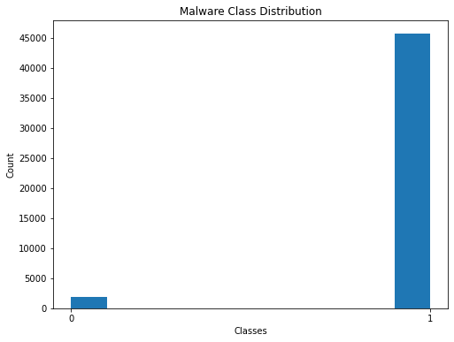

```python
plt.figure(figsize=(8, 6))
plt.hist(Malware['malware'])
plt.title("Malware Class Distribution")
plt.xticks([0,1])
plt.yticks([i for i in range(0,len(Malware),5000)])
plt.ylabel('Count')
plt.xlabel("Classes")
plt.show()
```

**Checking date types from dataset**

```python
list(set(Malware.dtypes.tolist()))
```

```
[dtype('O'), dtype('int64')]
```

**Since we only needed features with integeral values, we will be proceeding with those features**

```python
Malware_num = Malware.select_dtypes(include = ['int64'])
Malware_num.head()
```

|  | GetProcAddress | ExitProcess | WriteFile | GetLastError | CloseHandle | FreeLibrary | Sleep | GetStdHandle | MultiByteToWideChar | GetCurrentThreadId | ... | bind | RegEnumKeyExA | WinHttpOpen | _controlfp | WinExec | GetSecurityDescriptorDacl | FindFirstFreeAce | GetTimeFormatW | LookupAccountSidW | malware |
| --- | --- | --- | --- | --- | --- | --- | --- | --- | --- | --- | --- | --- | --- | --- | --- | --- | --- | --- | --- | --- | --- |
| 0 | 1 | 1 | 1 | 1 | 1 | 1 | 1 | 1 | 1 | 1 | ... | 0 | 0 | 0 | 0 | 0 | 0 | 0 | 0 | 0 | 1 |
| 1 | 1 | 1 | 1 | 1 | 1 | 1 | 1 | 1 | 1 | 1 | ... | 0 | 0 | 0 | 0 | 0 | 0 | 0 | 0 | 0 | 1 |
| 2 | 1 | 1 | 1 | 1 | 1 | 0 | 1 | 0 | 1 | 0 | ... | 0 | 1 | 0 | 0 | 0 | 0 | 0 | 0 | 0 | 1 |
| 3 | 1 | 1 | 1 | 1 | 0 | 0 | 1 | 1 | 1 | 1 | ... | 0 | 0 | 0 | 0 | 0 | 0 | 0 | 0 | 0 | 1 |
| 4 | 1 | 1 | 1 | 1 | 1 | 1 | 1 | 1 | 1 | 1 | ... | 0 | 0 | 0 | 0 | 0 | 0 | 0 | 0 | 0 | 1 |

5 rows × 1001 columns

**Checking feature co-relations**

```python
"""
Malware_num_corr = Malware_num.corr()['malware'][:-1] # -1 because the latest row is malware
golden_features_list = Malware_num_corr[abs(Malware_num_corr) > 0.5].sort_values(ascending=False)
print("There is {} strongly correlated values with Malware:\n{}".format(len(golden_features_list), golden_features_list))
"""
```

[output not shown]

```python
# Warning: This graph takes a lot of time
'''
corr = Malware_num.drop('malware', axis=1).corr() # We already examined malware correlations
plt.figure(figsize=(120, 100))

sns.heatmap(corr[(corr >= 0.5) | (corr <= -0.4)],
            cmap='viridis', vmax=1.0, vmin=-1.0, linewidths=0.1,
            annot=True, annot_kws={"size": 8}, square=True);


corrs = Malware_num.corr()['malware'][:-1]
figure = ff.create_annotated_heatmap(
    z=corrs.values,
    x=list(corrs.columns),
    y=list(corrs.index),
    annotation_text=corrs.round(2).values,
    showscale=True)
offline.plot(figure,filename='corrheatmap.html')
'''
```

[output not shown]

### 2. Data Pre-Processing

```python
# Checking if there are null values in the dataframe
Malware_num.isnull().sum()
```

```
GetProcAddress               0
ExitProcess                  0
WriteFile                    0
GetLastError                 0
CloseHandle                  0
                            ..
GetSecurityDescriptorDacl    0
FindFirstFreeAce             0
GetTimeFormatW               0
LookupAccountSidW            0
malware                      0
Length: 1001, dtype: int64
```

**Seperating independent & target features**

```python
# Independent Feature
X = Malware_num.drop('malware',axis=1)

# Dependent Feature
y = Malware_num['malware']
```

```python
X.head()
```

|  | GetProcAddress | ExitProcess | WriteFile | GetLastError | CloseHandle | FreeLibrary | Sleep | GetStdHandle | MultiByteToWideChar | GetCurrentThreadId | ... | DuplicateToken | bind | RegEnumKeyExA | WinHttpOpen | _controlfp | WinExec | GetSecurityDescriptorDacl | FindFirstFreeAce | GetTimeFormatW | LookupAccountSidW |
| --- | --- | --- | --- | --- | --- | --- | --- | --- | --- | --- | --- | --- | --- | --- | --- | --- | --- | --- | --- | --- | --- |
| 0 | 1 | 1 | 1 | 1 | 1 | 1 | 1 | 1 | 1 | 1 | ... | 0 | 0 | 0 | 0 | 0 | 0 | 0 | 0 | 0 | 0 |
| 1 | 1 | 1 | 1 | 1 | 1 | 1 | 1 | 1 | 1 | 1 | ... | 0 | 0 | 0 | 0 | 0 | 0 | 0 | 0 | 0 | 0 |
| 2 | 1 | 1 | 1 | 1 | 1 | 0 | 1 | 0 | 1 | 0 | ... | 0 | 0 | 1 | 0 | 0 | 0 | 0 | 0 | 0 | 0 |
| 3 | 1 | 1 | 1 | 1 | 0 | 0 | 1 | 1 | 1 | 1 | ... | 0 | 0 | 0 | 0 | 0 | 0 | 0 | 0 | 0 | 0 |
| 4 | 1 | 1 | 1 | 1 | 1 | 1 | 1 | 1 | 1 | 1 | ... | 0 | 0 | 0 | 0 | 0 | 0 | 0 | 0 | 0 | 0 |

5 rows × 1000 columns

```python
y.head()
```

```
0    1
1    1
2    1
3    1
4    1
Name: malware, dtype: int64
```

**Data normalization using standard scalar**

```python
X = StandardScaler().fit_transform(X)
X
```

```
array([[ 0.38272496,  0.42488585,  0.56194501, ..., -0.15730988,
        -0.15660697, -0.15575969],
       [ 0.38272496,  0.42488585,  0.56194501, ..., -0.15730988,
        -0.15660697, -0.15575969],
       [ 0.38272496,  0.42488585,  0.56194501, ..., -0.15730988,
        -0.15660697, -0.15575969],
       ...,
       [ 0.38272496,  0.42488585,  0.56194501, ..., -0.15730988,
        -0.15660697, -0.15575969],
       [ 0.38272496,  0.42488585,  0.56194501, ..., -0.15730988,
        -0.15660697, -0.15575969],
       [ 0.38272496, -2.35357331, -1.77953355, ..., -0.15730988,
        -0.15660697, -0.15575969]])
```

**Identifying the number of clusters for PCA using Elbow Curve**

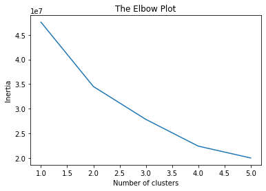

```python
# Finding the number of clusters (K) - Elbow Plot Method
inertia = []
for i in range(1,6):
    kmeans = KMeans(n_clusters = i, random_state = 100)
    kmeans.fit(X)
    inertia.append(kmeans.inertia_)

#Displaying the Elbow Plot
plt.plot(range(1, 6), inertia)
plt.title('The Elbow Plot')
plt.xlabel('Number of clusters')
plt.ylabel('Inertia')
plt.show()
```

**Reducing the number of features by dimensionality reduction technique: PCA**

```python
# Taking n_components=3 since the above Elbow graph show a dip in between cluster 2 & 4. Hence taking a mid of these two values.
pca = PCA(n_components=3)
x_pca = pca.fit_transform(X)
principalDf = pd.DataFrame(data = x_pca
             , columns = ['principal component 1', 'principal component 2','principal component 3'])
```

```python
print("Variance explained by each of the n_components: ",pca.explained_variance_ratio_)
print("Total variance explained by the n_components: ",sum(pca.explained_variance_ratio_))
```

```
Variance explained by each of the n_components:  [0.29609635 0.15175011 0.11404015]
Total variance explained by the n_components:  0.5618866045534284
```

**Creating a 3-D Graph to visualize the new generated components.**

```python
fig = px.scatter_3d(x_pca, x=x_pca[:,0], y=x_pca[:,1], z=x_pca[:,2],
              color=y)
#fig = go.Figure(data=data, layout=layout)
offline.plot(fig,filename='pca.html')
```

```
'pca.html'
```

**Resetting the indexes of the newly created PCA dataset.**

```python
principalDf.reset_index(drop=True, inplace=True)
Malware_num['malware'].reset_index(drop=True, inplace=True)
```

```python
finalDf = pd.concat([principalDf, Malware_num['malware']], axis=1)
```

```python
finalDf
```

|  | principal component 1 | principal component 2 | principal component 3 | malware |
| --- | --- | --- | --- | --- |
| 0 | 24.845661 | 29.748642 | -15.208199 | 1 |
| 1 | -3.332297 | -11.623093 | -11.708633 | 1 |
| 2 | -9.905983 | 4.917449 | 6.548310 | 1 |
| 3 | -10.738613 | 2.043849 | 4.621539 | 1 |
| 4 | -5.088848 | -14.828116 | -17.008388 | 1 |
| ... | ... | ... | ... | ... |
| 47575 | -5.088848 | -14.828116 | -17.008388 | 1 |
| 47576 | -5.088848 | -14.828116 | -17.008388 | 1 |
| 47577 | -5.088848 | -14.828116 | -17.008388 | 1 |
| 47578 | 24.845661 | 29.748642 | -15.208199 | 1 |
| 47579 | -9.479028 | 2.431943 | 8.021710 | 0 |

47580 rows × 4 columns

**Splitting the principal component analysed dataset into dependent and target feature.**

```python
X=finalDf.drop('malware',axis=1)
```

```python
y=finalDf['malware']
```

```python
X.info()
```

```
<class 'pandas.core.frame.DataFrame'>
RangeIndex: 47580 entries, 0 to 47579
Data columns (total 3 columns):
 #   Column                 Non-Null Count  Dtype
---  ------                 --------------  -----
 0   principal component 1  47580 non-null  float64
 1   principal component 2  47580 non-null  float64
 2   principal component 3  47580 non-null  float64
dtypes: float64(3)
memory usage: 1.1 MB
```

**Splitting the dataset in train and test set**

```python
X_train,X_test,y_train,y_test=train_test_split(X.values,y.values,test_size=(0.30),random_state=42)
```

```python
print(f'X_train shape: {X_train.shape}')
print(f'y_train shape:{y_train.shape}')
print(f'X_test shape: {X_test.shape}')
print(f'y_test shape: {y_test.shape}')
```

```
X_train shape: (33306, 3)
y_train shape:(33306,)
X_test shape: (14274, 3)
y_test shape: (14274,)
```

```python
print("Number of observations in each class before oversampling (training data): \n", pd.Series(y_train).value_counts())
```

```
Number of observations in each class before oversampling (training data):
 1    31997
0     1309
dtype: int64
```

**Balancing the classes through Synthetic Minority Over-sampling Technique (SMOTE)**

```python
sm = SMOTE(random_state=42)
X_train, y_train = sm.fit_resample(X_train, y_train)
print("Number of observations in each class after oversampling (training data): \n", pd.Series(y_train).value_counts())
```

```
Number of observations in each class after oversampling (training data):
 1    31997
0    31997
dtype: int64
```

```python
print(y_train.shape)
print(y_test.shape)
```

```
(63994,)
(14274,)
```

```python
y_test
```

```
array([1, 1, 1, ..., 1, 1, 1], dtype=int64)
```

### Model Building and Evaluation

```python
# A list to store models performance metrics
model_eval_list = []
```

**A method for plotting confusion matrix**

```python
def plot_confusion_matrix(cm):
    fig, ax = plt.subplots(figsize=(6,4))
    sns.heatmap(cm, cmap='RdYlBu', annot=True, fmt = 'd', annot_kws= {'size':16})
    sns.set(font_scale= 1.5)
    bottom,top = ax.get_ylim()
    #ax.set_ylim(bottom +0.5, top - 0.5)
    plt.ylabel('Actual')
    plt.xlabel('Predicted')
    plt.show()
```

**1. XG Boost**

```
Accuracy: 87.5%
precision: 99.49%
recall: 87.38%
f1_score: 93.04%
Confusion Matrix
 [[  559    61]
 [ 1723 11931]]
```

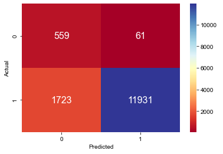

```python
import xgboost as xgb

D_train = xgb.DMatrix(X_train, label = y_train)
D_test = xgb.DMatrix(X_test, label= y_test)

param = {
    'eta': 0.2,
    'max_depth': 3,
    'objective': 'multi:softprob',
    'num_class': 2}
param['eval_metric'] = 'auc'
steps = 100  # The number of training iterations

model = xgb.train(param, D_train, steps)

preds = model.predict(D_test)

best_preds = np.asarray([np.argmax(line) for line in preds])

score = accuracy_score(y_test, best_preds)
print(f'Accuracy: {round(score*100,2)}%')
result=(score*100)
precision = precision_score(y_test, best_preds)
print(f'precision: {round(precision*100,2)}%')
recall = recall_score(y_test, best_preds)
print(f'recall: {round(recall*100,2)}%' )
f1 = f1_score(y_test, best_preds)
print(f'f1_score: {round(f1*100,2)}%')


eval_dict={}
eval_dict["Classifier"] = model.__class__.__name__
eval_dict["Precision"] = precision
eval_dict["Recall"] = recall
eval_dict["F1_Score"] = f1
eval_dict["Accuracy"] = result
model_eval_list.append(eval_dict)
model_eval_list.append(eval_dict)
cm = confusion_matrix(y_test, best_preds)
print('Confusion Matrix \n',cm)
plot_confusion_matrix(cm)
#sns.heatmap(cm, annot=True)
```

**2. XGB Classifier**

```
Accuracy:97.00%
precision: 99.39%
recall: 92.59%
f1_score: 95.87%
Confusion Matrix
 [[  542    78]
 [ 1012 12642]]
```

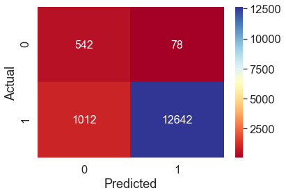

```python
from sklearn.model_selection import KFold
from sklearn.model_selection import cross_val_score
from xgboost import XGBClassifier

model = XGBClassifier()

model.fit(X_train,y_train)

pred = model.predict(X_test)

kfold = KFold(n_splits=10, random_state=7)
results = cross_val_score(model, X, y, cv=kfold)
print("Accuracy:%.2f%%" % (results.mean()*100))
result=(results.mean()*100)
precision = precision_score(y_test, pred)
print(f'precision: {round(precision*100,2)}%')
recall = recall_score(y_test, pred)
print(f'recall: {round(recall*100,2)}%' )
f1 = f1_score(y_test, pred)
print(f'f1_score: {round(f1*100,2)}%')


eval_dict={}
eval_dict["Classifier"] = model.__class__.__name__
eval_dict["Precision"] = precision
eval_dict["Recall"] = recall
eval_dict["F1_Score"]=f1
eval_dict["Accuracy"] = result
model_eval_list.append(eval_dict)
cm = confusion_matrix(y_test, pred)
print('Confusion Matrix \n',cm)
plot_confusion_matrix(cm)
#sns.heatmap(cm, annot=True)
```

**3. XGBR Classifier**

```
Accuracy: 84.13%
precision: 99.24%
recall: 84.06%
f1_score: 91.02%
Confusion Matrix
 [[  532    88]
 [ 2177 11477]]
```

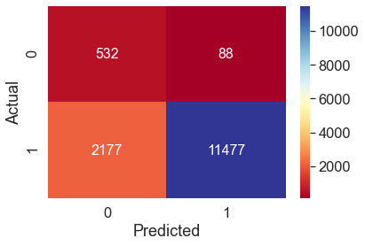

```python
from xgboost import XGBRFClassifier

model = XGBRFClassifier()

model.fit(X_train,y_train)

pred = model.predict(X_test)

score = accuracy_score(y_test, pred)
print(f'Accuracy: {round(score*100,2)}%')
result=(score*100)
precision = precision_score(y_test, pred)
print(f'precision: {round(precision*100,2)}%')
recall = recall_score(y_test, pred)
print(f'recall: {round(recall*100,2)}%' )
f1 = f1_score(y_test, pred)
print(f'f1_score: {round(f1*100,2)}%')


eval_dict={}
eval_dict["Classifier"] = model.__class__.__name__
eval_dict["Precision"] = precision
eval_dict["Recall"] = recall
eval_dict["F1_Score"]=f1
eval_dict["Accuracy"] = result
model_eval_list.append(eval_dict)

cm = confusion_matrix(y_test, pred)
print('Confusion Matrix \n',cm)
plot_confusion_matrix(cm)
#sns.heatmap(cm, annot=True)
```

**4. Decision Tree Classifier Using Gini Index**

```
Accuracy:96.41%
precision: 98.25%
recall: 86.28%
f1_score: 91.87%
Confusion Matrix
 [[  410   210]
 [ 1874 11780]]
```

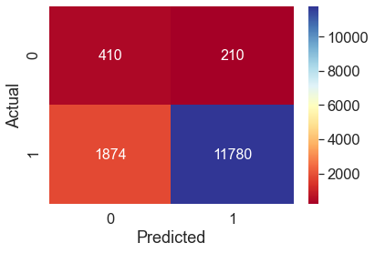

```python
from sklearn.model_selection import cross_val_score
from sklearn.tree import DecisionTreeClassifier

model = DecisionTreeClassifier(criterion = "gini",
            random_state = 100,max_depth=3, min_samples_leaf=5)

model.fit(X_train, y_train)

pred = model.predict(X_test)

model = DecisionTreeClassifier(criterion='gini')
tree_scores = cross_val_score(model, X, y, cv=4)
print("Accuracy:%.2f%%" % (tree_scores.mean()*100))
result=(tree_scores.mean()*100)
precision = precision_score(y_test, pred)
print(f'precision: {round(precision*100,2)}%')
recall = recall_score(y_test, pred)
print(f'recall: {round(recall*100,2)}%' )
f1 = f1_score(y_test, pred)
print(f'f1_score: {round(f1*100,2)}%')


eval_dict={}
eval_dict["Classifier"] = model.__class__.__name__+"_gini"
eval_dict["Precision"] = precision
eval_dict["Recall"] = recall
eval_dict["F1_Score"]=f1
eval_dict["Accuracy"] = result
model_eval_list.append(eval_dict)


cm = confusion_matrix(y_test, pred)
print('Confusion Matrix \n',cm)
plot_confusion_matrix(cm)
#sns.heatmap(cm, annot=True)
```

**5. Decision Tree Classifier Using Entropy**

```
Accuracy:95.94%
precision: 98.22%
recall: 86.31%
f1_score: 91.88%
Confusion Matrix
 [[  406   214]
 [ 1869 11785]]
```

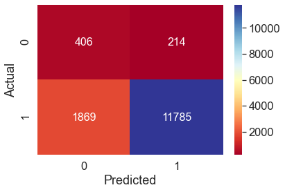

```python
model = DecisionTreeClassifier(criterion = "entropy",
            random_state = 100,max_depth=3, min_samples_leaf=5)

model.fit(X_train, y_train)

pred = model.predict(X_test)
tree_scores = cross_val_score(model, X, y, cv=4)
print("Accuracy:%.2f%%" % (tree_scores.mean()*100))
result=(tree_scores.mean()*100)
precision = precision_score(y_test, pred)
print(f'precision: {round(precision*100,2)}%')
recall = recall_score(y_test, pred)
print(f'recall: {round(recall*100,2)}%' )
f1 = f1_score(y_test, pred)
print(f'f1_score: {round(f1*100,2)}%')
eval_dict={}
eval_dict["Classifier"] = model.__class__.__name__+"_entropy"
eval_dict["Precision"] = precision
eval_dict["Recall"] = recall
eval_dict["F1_Score"]=f1
eval_dict["Accuracy"] = result
model_eval_list.append(eval_dict)


cm = confusion_matrix(y_test, pred)
print('Confusion Matrix \n',cm)
plot_confusion_matrix(cm)
#sns.heatmap(cm, annot=True)
```

**6. Random Forest Classifier**

```python
from sklearn.ensemble import RandomForestClassifier
from sklearn.model_selection import GridSearchCV

#Tuning the random forest parameter 'n_estimators' and implementing cross-validation using Grid Search
rfc = RandomForestClassifier(criterion='entropy', max_features='auto', random_state=1)
```

**Using grid search to find best parameters for grid search**

```python
grid_param = {'n_estimators': [50, 100, 150, 200, 250, 300,350,400]}
gd_sr = GridSearchCV(estimator=rfc, param_grid=grid_param, scoring='accuracy', cv=5)
```

**Fitting model to random forest classifier**

```
{'n_estimators': 250}
95.96681502541105
precision: 99.22%
recall: 95.15%
f1_score: 97.14%
Confusion Matrix
 [[  518   102]
 [  662 12992]]
```

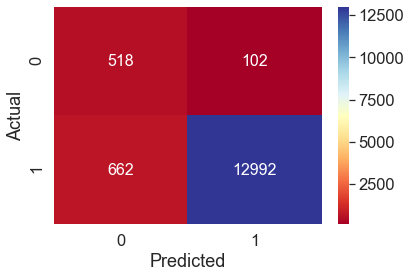

```python
gd_sr.fit(X_train,y_train)

best_parameters = gd_sr.best_params_
print(best_parameters)

best_result = gd_sr.best_score_ # Mean cross-validated score of the best_estimator
print(best_result*100)
result=(best_result*100)
# #Building random forest using the tuned parameter
rfc = RandomForestClassifier(n_estimators=100, criterion='entropy', max_features='auto', random_state=1)
rfc.fit(X_train,y_train)

pred = rfc.predict(X_test)
precision = precision_score(y_test, pred)
print(f'precision: {round(precision*100,2)}%')
recall = recall_score(y_test, pred)
print(f'recall: {round(recall*100,2)}%' )
f1 = f1_score(y_test, pred)
print(f'f1_score: {round(f1*100,2)}%')
eval_dict={}
eval_dict["Classifier"] = rfc.__class__.__name__
eval_dict["Precision"] = precision
eval_dict["Recall"] = recall
eval_dict["F1_Score"]=f1
eval_dict["Accuracy"] = result
model_eval_list.append(eval_dict)


cm = confusion_matrix(y_test, pred)
print('Confusion Matrix \n',cm)
plot_confusion_matrix(cm)
#sns.heatmap(cm, annot=True)
```

**7. SVM Classifier**

```
Classifier = LinearSVC
Accuracy: 95.95%
precision: 97.9%
recall: 36.9%
f1_score: 53.6%
Confusion Matrix
 [[ 512  108]
 [8615 5039]]
```

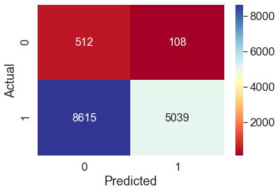

```python
from sklearn.svm import LinearSVC
svm=LinearSVC()
svm_scores = cross_val_score(svm, X, y, cv=2 )
model=svm.fit(X_train,y_train)
pred = model.predict(X_test)
#print(" Accuracy SVMs:".format(svm_scores.mean()))
print("Classifier = "+model.__class__.__name__)
print(f'Accuracy: {round(svm_scores.mean()*100,2)}%')
result=(svm_scores.mean()*100)
precision = precision_score(y_test, pred)
print(f'precision: {round(precision*100,2)}%')
recall = recall_score(y_test, pred)
print(f'recall: {round(recall*100,2)}%' )
f1 = f1_score(y_test, pred)
print(f'f1_score: {round(f1*100,2)}%')


eval_dict={}
eval_dict["Classifier"] = ""+model.__class__.__name__
eval_dict["Precision"] = precision
eval_dict["Recall"] = recall
eval_dict['F1_Score']=f1
eval_dict["Accuracy"] = result
model_eval_list.append(eval_dict)
cm = confusion_matrix(y_test, pred)
print('Confusion Matrix \n',cm)
plot_confusion_matrix(cm)
#sns.heatmap(cm, annot=True)
```

**8. KNN classifier**

```
Classifier = KNeighborsClassifier
Accuracy: 96.8%
precision: 99.01%
recall: 94.84%
f1_score: 96.88%
Confusion Matrix
 [[  490   130]
 [  705 12949]]
```

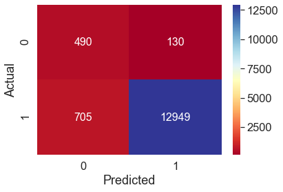

```python
from sklearn.neighbors import KNeighborsClassifier
kNN = KNeighborsClassifier(n_neighbors=3)
kNN_scores = cross_val_score(kNN, X, y, cv=4)
#print("CV Accuracy kNNs:".format(kNN_scores.mean()))
model=kNN.fit(X_train,y_train)
pred = model.predict(X_test)
print("Classifier = "+model.__class__.__name__)
print(f'Accuracy: {round(kNN_scores.mean()*100,2)}%')
result=(kNN_scores.mean()*100)
precision = precision_score(y_test, pred)
print(f'precision: {round(precision*100,2)}%')
recall = recall_score(y_test, pred)
print(f'recall: {round(recall*100,2)}%' )
f1 = f1_score(y_test, pred)
print(f'f1_score: {round(f1*100,2)}%')


eval_dict={}
eval_dict["Classifier"] = ""+model.__class__.__name__
eval_dict["Precision"] = precision
eval_dict["Recall"] = recall
eval_dict['F1_Score']=f1
eval_dict["Accuracy"] = result
model_eval_list.append(eval_dict)
cm = confusion_matrix(y_test, pred)
print('Confusion Matrix \n',cm)
plot_confusion_matrix(cm)
#sns.heatmap(cm, annot=True)
```

```
Classifier = RidgeClassifier
Accuracy: 47.27%
precision: 98.22%
recall: 45.7%
f1_score: 62.38%
Confusion Matrix
 [[ 507  113]
 [7414 6240]]
```

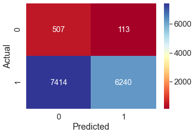

```python
from sklearn.linear_model import RidgeClassifier
from sklearn.ensemble import BaggingClassifier
rg = RidgeClassifier()
clf_array = [rg]
for clf in clf_array:
    model = BaggingClassifier(clf, max_features=3, random_state=42)

    model.fit(X_train, y_train)
    pred = model.predict(X_test)
    print("Classifier = "+clf.__class__.__name__)
    score = accuracy_score(y_test, pred)
    print(f'Accuracy: {round(score*100,2)}%')
    result=(score*100)
    precision = precision_score(y_test, pred)
    print(f'precision: {round(precision*100,2)}%')
    recall = recall_score(y_test, pred)
    print(f'recall: {round(recall*100,2)}%' )
    f1 = f1_score(y_test, pred)
    print(f'f1_score: {round(f1*100,2)}%')

    eval_dict={}
    eval_dict["Classifier"] = "Bagging_"+clf.__class__.__name__
    eval_dict["Precision"] = precision
    eval_dict["Recall"] = recall
    eval_dict['F1_Score']=f1
    eval_dict["Accuracy"] = result
    model_eval_list.append(eval_dict)
    cm = confusion_matrix(y_test, pred)
    print('Confusion Matrix \n',cm)
    plot_confusion_matrix(cm)
    #sns.heatmap(cm, annot=True)
```

**10. AdaBoost Classifier**

```
Accuracy: 59.32%
precision: 99.41%
recall: 57.82%
f1_score: 73.12%
Confusion Matrix
 [[ 573   47]
 [5759 7895]]
```

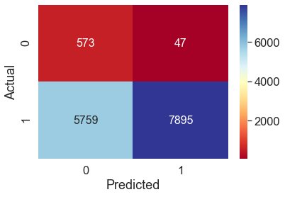

```python
from sklearn.ensemble import AdaBoostClassifier

model = AdaBoostClassifier(n_estimators=100, base_estimator= None,learning_rate=0.01, random_state = 1)

model.fit(X_train, y_train)
pred = model.predict(X_test)

score = accuracy_score(y_test, pred)
print(f'Accuracy: {round(score*100,2)}%')
result=(score*100)
precision = precision_score(y_test, pred)
print(f'precision: {round(precision*100,2)}%')
recall = recall_score(y_test, pred)
print(f'recall: {round(recall*100,2)}%' )
f1 = f1_score(y_test, pred)
print(f'f1_score: {round(f1*100,2)}%')
eval_dict={}
eval_dict["Classifier"] = model.__class__.__name__
eval_dict["Precision"] = precision
eval_dict["Recall"] = recall
eval_dict['F1_Score']=f1
eval_dict["Accuracy"] = result
model_eval_list.append(eval_dict)

cm = confusion_matrix(y_test, pred)
print('Confusion Matrix \n',cm)
plot_confusion_matrix(cm)
#sns.heatmap(cm, annot=True)
```

```
Accuracy: 84.8%
precision: 99.09%
recall: 84.9%
f1_score: 91.44%
Confusion Matrix
 [[  513   107]
 [ 2062 11592]]
```

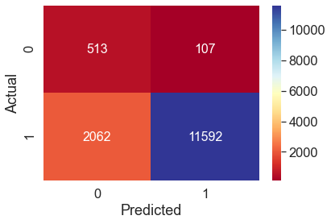

```python
from sklearn.ensemble import GradientBoostingClassifier

model = GradientBoostingClassifier(
    max_depth=2,
    n_estimators=3,
    learning_rate=0.9)

model.fit(X_train, y_train)

pred = model.predict(X_test)

score = accuracy_score(y_test, pred)
print(f'Accuracy: {round(score*100,2)}%')
result=(score*100)
precision = precision_score(y_test, pred)
print(f'precision: {round(precision*100,2)}%')
recall = recall_score(y_test, pred)
print(f'recall: {round(recall*100,2)}%' )
f1 = f1_score(y_test, pred)
print(f'f1_score: {round(f1*100,2)}%')
eval_dict={}
eval_dict["Classifier"] = model.__class__.__name__
eval_dict["Precision"] = precision
eval_dict["Recall"] = recall
eval_dict['F1_Score']=f1
eval_dict["Accuracy"] = result
model_eval_list.append(eval_dict)
cm = confusion_matrix(y_test, pred)
print('Confusion Matrix \n',cm)
plot_confusion_matrix(cm)
#sns.heatmap(cm, annot=True)
```

**12. LogisticRegressionCV Classifier**

```
Accuracy: 47.86%
precision: 98.14%
recall: 46.37%
f1_score: 62.98%
Confusion Matrix
 [[ 500  120]
 [7323 6331]]
```

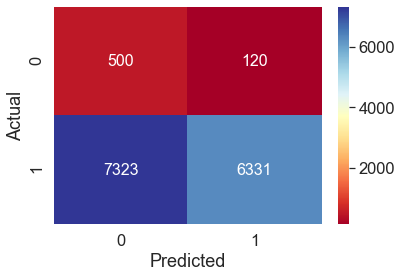

```python
from sklearn.linear_model import LogisticRegressionCV

model = LogisticRegressionCV(cv=4, random_state=0)

model.fit(X_train, y_train)

pred = model.predict(X_test)

score = accuracy_score(y_test, pred)
print(f'Accuracy: {round(score.mean()*100,2)}%')
result=(score.mean()*100)
precision = precision_score(y_test, pred)
print(f'precision: {round(precision*100,2)}%')
recall = recall_score(y_test, pred)
print(f'recall: {round(recall*100,2)}%' )
f1 = f1_score(y_test, pred)
print(f'f1_score: {round(f1*100,2)}%')
eval_dict={}
eval_dict["Classifier"] = model.__class__.__name__
eval_dict["Precision"] = precision
eval_dict["Recall"] = recall
eval_dict['F1_Score']=f1
eval_dict["Accuracy"] = result
model_eval_list.append(eval_dict)

cm = confusion_matrix(y_test, pred)
print('Confusion Matrix \n',cm)
plot_confusion_matrix(cm)
#sns.heatmap(cm, annot=True)
```

**14. Classification through ANN**

```python
#Importing the Keras Libraries & Packages
from keras.models import Sequential
from keras.layers import Dense
```

```python
#Initialize the ANN
classifier = Sequential()

#Adding the input layer and the first hidden layer
classifier.add(Dense(units = 6, kernel_initializer = 'uniform',activation = 'relu', input_shape = (3,)))

#Adding the second hidden layer
classifier.add(Dense(units = 6, kernel_initializer = 'uniform',activation = 'relu'))

#Adding the output layer
classifier.add(Dense(units = 1, kernel_initializer = 'uniform',activation = 'sigmoid'))

#Compiling the ANN
classifier.compile(optimizer = 'adam', loss = 'binary_crossentropy', metrics= ['accuracy'] )

#Fitting the ANN to the training set
classifier.fit(X_train, y_train, batch_size = 10, epochs = 10)
```

```
<keras.callbacks.callbacks.History at 0x267986d1c48>
```

```
[[ True]
 [ True]
 [ True]
 ...
 [ True]
 [ True]
 [ True]]
0.8635981504833964
```

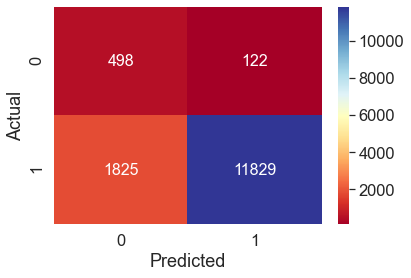

```python
#Predicting the test set results
y_pred = classifier.predict(X_test)
y_pred = (y_pred> 0.5)  #If y_pred>0.5 then true(1) else False(0)
print(y_pred)
acc = accuracy_score(y_pred,y_test)
print(acc)
cm = confusion_matrix(y_test,y_pred)
plot_confusion_matrix(cm)
```

```python
df_eval = model_eval_list
```

```python
# Evaluating, Improving and Tuning the ANN
from keras.models import Sequential
from keras.layers import Dense
from keras.wrappers.scikit_learn import KerasClassifier
from sklearn.model_selection import cross_val_score

def build_classifier():
    classifier = Sequential()
    classifier.add(Dense(units = 6, kernel_initializer = 'uniform', activation='relu', input_shape=(3,)))
    classifier.add(Dense(units = 6, kernel_initializer = 'uniform', activation='relu'))
    classifier.add(Dense(units = 1, kernel_initializer = 'uniform', activation = 'sigmoid'))
    classifier.compile(optimizer = 'adam', loss = 'binary_crossentropy', metrics= ['accuracy'] )
    return classifier

classifier = KerasClassifier(build_fn = build_classifier, batch_size = 10, epochs = 10 )
accuracies = cross_val_score(estimator = classifier, X = X_train, y = y_train, cv = 2)
mean = accuracies.mean()
variance = accuracies.std()
```

**Checking Mean and Variance**

```python
print(mean)
print(variance)
```

```
0.18189205043017864
0.12535549886524677
```

**Dealing with Overfitting**

```python
from keras.models import Sequential
from keras.layers import Dense
from keras.layers import Dropout
classifier = Sequential()
#Adding the input layer and the first hidden layer
classifier.add(Dense(units = 6, kernel_initializer = 'uniform',activation = 'relu', input_shape = (3,)))
classifier.add(Dropout(rate = 0.1))
#Adding the second hidden layer
classifier.add(Dense(units = 6, kernel_initializer = 'uniform',activation = 'relu'))
classifier.add(Dropout(rate = 0.1))

#Adding the output layer
classifier.add(Dense(units = 1, kernel_initializer = 'uniform',activation = 'sigmoid'))

#Compiling the ANN
classifier.compile(optimizer = 'adam', loss = 'binary_crossentropy', metrics= ['accuracy'] )

#Fitting the ANN to the training set
classifier.fit(X_train, y_train, batch_size = 10, epochs = 10)
```

```
<keras.callbacks.callbacks.History at 0x267995caf08>
```

**Storing evaluation metrics in a dictionary**

```python
accuracy_score(y_test,y_pred)*100
score = accuracy_score(y_test, y_pred)
print(f'Accuracy: {round(score.mean()*100,2)}%')
result=(score.mean()*100)
precision = precision_score(y_test, y_pred)
print(f'precision: {round(precision*100,2)}%')
recall = recall_score(y_test, y_pred)
print(f'recall: {round(recall*100,2)}%' )
f1 = f1_score(y_test, y_pred)
print(f'f1_score: {round(f1*100,2)}%')
eval_dict={}
eval_dict["Classifier"] ="ANN"
eval_dict["Precision"] = precision
eval_dict["Recall"] = recall
eval_dict['F1_Score']=f1
eval_dict["Accuracy"] = result
model_eval_list.append(eval_dict)
```

```
Accuracy: 86.36%
precision: 98.98%
recall: 86.63%
f1_score: 92.4%
```

### Combining evaluation metrics of all classifiers

```python
eval_df = pd.DataFrame(model_eval_list)
eval_df
```

|  | Classifier | Precision | Recall | F1_Score | Accuracy |
| --- | --- | --- | --- | --- | --- |
| 0 | Booster | 0.994913 | 0.873810 | 0.930437 | 87.501751 |
| 1 | Booster | 0.994913 | 0.873810 | 0.930437 | 87.501751 |
| 2 | XGBClassifier | 0.993868 | 0.925883 | 0.958671 | 96.996637 |
| 3 | XGBRFClassifier | 0.992391 | 0.840560 | 0.910187 | 84.131988 |
| 4 | DecisionTreeClassifier_gini | 0.982485 | 0.862751 | 0.918733 | 96.408155 |
| 5 | DecisionTreeClassifier_entropy | 0.982165 | 0.863117 | 0.918801 | 95.943674 |
| 6 | RandomForestClassifier | 0.992210 | 0.951516 | 0.971437 | 95.966815 |
| 7 | LinearSVC | 0.979017 | 0.369049 | 0.536035 | 95.945776 |
| 8 | KNeighborsClassifier | 0.990060 | 0.948367 | 0.968765 | 96.799075 |
| 9 | Bagging_RidgeClassifier | 0.982213 | 0.457009 | 0.623782 | 47.267760 |
| 10 | AdaBoostClassifier | 0.994082 | 0.578219 | 0.731154 | 59.324646 |
| 11 | GradientBoostingClassifier | 0.990854 | 0.848982 | 0.914448 | 84.804540 |
| 12 | LogisticRegressionCV | 0.981398 | 0.463674 | 0.629794 | 47.856242 |
| 13 | ANN | 0.989792 | 0.866340 | 0.923960 | 86.359815 |